# Project 5: Data Visualization

## Causes of Delays

- So we now know that there are no cascading delays. Now we need to know the causes of delays and in what time category do most delays occur in.
- I have established that there are correlations between CarrierDelay, WeatherDelay, NASDelay, SecurityDelay, LateAircraftDelay and target columns DepDelayM, ArrDelayM. Now I will explore further.

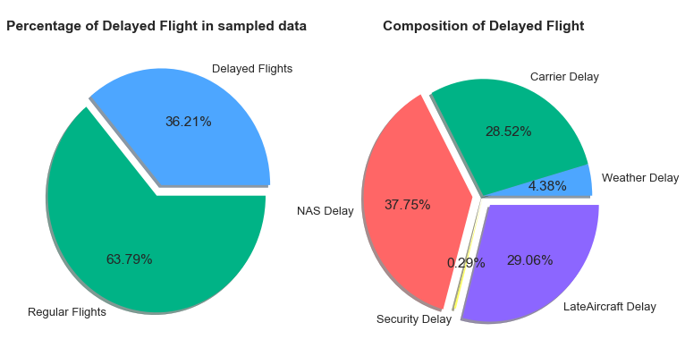

```python
fig = plt.figure(figsize=[12,6])

ax1 = fig.add_subplot(1,2,1)
labels=['Delayed Flights','Regular Flights']
explode = (0.1,0)
plt.pie(data,autopct='%1.2f%%',labels=labels,shadow=True,explode=explode)
plt.title('\nPercentage of Delayed Flight in sampled data\n',weight='bold')


ax2 = fig.add_subplot(1,2,2)
explode = (0,0,0.1,0,0.1)
labels = ['Weather Delay','Carrier Delay','NAS Delay','Security Delay','LateAircraft Delay']
plt.pie(delay_list,autopct='%1.2f%%',labels=labels,shadow=True,explode=explode)
plt.title('\nComposition of Delayed Flight\n',weight='bold')

plt.show()
```

#### Observations on Delayed Flight

- Delayed Flights consist of 36.21% of total flights. (Remember that this a sampled data. Although by statistical inference, it represents total population)
- The three main causes of delays are NAS, LateAircarft, and Carrier. The two minor causes of delay are Weather and Security.

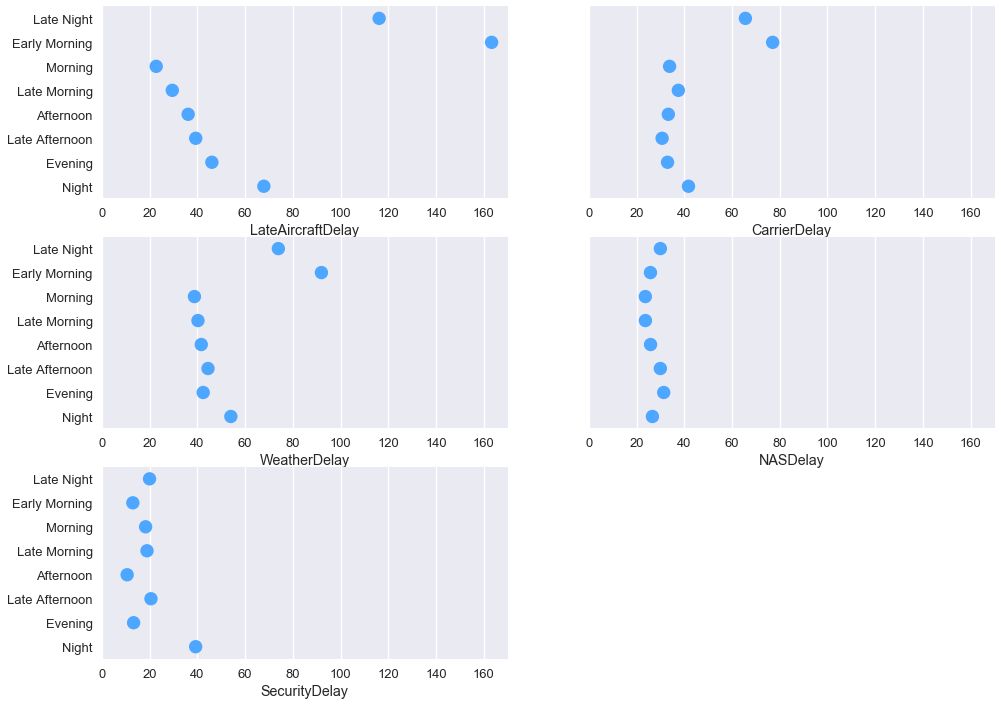

```python
fig = plt.figure(figsize=[16,12])
ax1 = fig.add_subplot(3,2,1)

sb.pointplot(data=lateaircraft_delay_df,x='LateAircraftDelay',ci=None,linestyles='',y='DepTimeCategory')
plt.xlim(0,170)
plt.ylabel('')

ax2 = fig.add_subplot(3,2,2)
sb.pointplot(data=carrier_delay_df,x='CarrierDelay',ci=None,linestyles='',y='DepTimeCategory',dodge=0.3)
plt.xlim(0,170)
plt.ylabel('')
plt.yticks([])


ax3 = fig.add_subplot(3,2,3)
sb.pointplot(data=weather_delay_df,x='WeatherDelay',ci=None,linestyles='',y='DepTimeCategory',dodge=0.3)
plt.xlim(0,170)
plt.ylabel('')

ax4 = fig.add_subplot(3,2,4)
plt.xlim(0,170)
sb.pointplot(data=nas_delay_df,x='NASDelay',ci=None,linestyles='',y='DepTimeCategory')
plt.ylabel('')
plt.yticks([])

ax5 = fig.add_subplot(3,2,5)
sb.pointplot(data=security_delay_df,x='SecurityDelay',ci=None,linestyles='',y='DepTimeCategory')
plt.xlim(0,170)
plt.ylabel('')

plt.show()
```

- Three plots stand out: 1. LateAircraftDelay, 2. CarrierDelay, and 3. Weather Delay.
- They stand out because longest delays happen at LateNight and EarlyMorning. Their mean delays in LateNight and EarlyMorning category are above mean average.
- Taken together, data from these three categories make up around 62% of total delayed data (29.06 + 28.52 + 4.38).
- Therefore, the trend we observe previously (Section 5.2, Section 5.3, and Section 5.4) is not due to cascading delays. It is due to delays caused by LateAircraftDelay, CarrierDelay and WeatherDelay that happened longer at LateNight and EarlyMorning. Also Read Section 5.5, if you need convincing that delays are not cascaded through the day.

```python
fig = plot_go_scattermapbox(big_v_long_delay_df,big_long_delay_df,big_mid_delay_df,big_small_delay_df,\
            '<b>Departure Delay time of Big Airports in minutes</b><br>(Hover for Airport Name and delay time)')
py.iplot(fig, filename='DelayTime_BigAirports')
```

[interactive chart not shown]

#### Observations on Departure Delay Time of Big Airports

- There are more big-sized airports on the eastern coastal cities than western coastal cities.
- The big-sized airports on the western coastal cities experience shorter mean delays. Plase hover over the circle for aiport name and mean delay time in minutes.
- The big-sized airports on the central and eastern coastal cities experience longer delays denoted by red, yellow and green circles on the map.

```python
fig = plot_go_scattermapbox(mid_v_long_delay_df,mid_long_delay_df,mid_mid_delay_df,mid_small_delay_df,\
            '<b>Departure Delay time of Mid-Size Airports in minutes</b><br>(Hover for Airport Name and delay time)')
py.iplot(fig, filename='DelayTime_MidAirports')
```

[interactive chart not shown]

#### Observations on Departure Delay Time of Mid-size Airports

- There are more mid-sized airports on the eastern coastal cities than western coastal cities.
- The mid-size airports suffer longer departure delays than big-size airports. There are more red and yellow circles on mid-size Airport map.

```python
fig = plot_go_scattermapbox(small_v_long_delay_df,small_long_delay_df,small_mid_delay_df,small_small_delay_df,\
            '<b>Departure Delay time of Small-Size Airports in minutes</b><br>(Hover for Airport Name and delay time)')
py.iplot(fig, filename='DelayTime_SmallAirports')
```

[interactive chart not shown]

#### Observations on Departure Delay Time of Small-Size Airports

- There are more small-sized airports on the eastern coastal cities and central cities than western coastal cities.
- The small-size airports suffer longer departure delays than big-size airports. There are more red and yellow circles on small-size Airport map.
- Please hover over the circle for aiport name and mean delay time in minutes.

```python
fig = plot_go_scattermapbox(vsmall_v_long_delay_df,vsmall_long_delay_df,vsmall_mid_delay_df,vsmall_small_delay_df,\
            '<b>Departure Delay time of Very Small-Size Airports in minutes</b><br>(Hover for Airport Name and delay time)')
py.iplot(fig, filename='DelayTime_VSmallAirports')
```

[interactive chart not shown]

#### Observations on Departure Delay Time of Very Small-Size Airports

- Airports are evenly distributed on eastern, central, and wester cities on very small-size airport map.
- Airports on the eastern coastal cities and central cities experience longer mean delays than western coastal cities. There are more red circles.
- The very small-size airports suffer longer mean departure delays than big-size airports. There are more red circles on very small-size Airport map.
- Please hover over the circle for aiport name and mean delay time in minutes.

```python
fig = plot_arr_go_scattermapbox(arr_big_v_long_delay_df,arr_big_long_delay_df,arr_big_mid_delay_df,arr_big_small_delay_df,\
            '<b>Arrival Delay time of Big Airports in minutes</b><br>(Hover for Airport Name and delay time)')
py.iplot(fig, filename='ArrivalTime_BigAirports')
```

[interactive chart not shown]

#### Observations on Arrival Delay Time of Big Airports

- There are more big-sized airports on the eastern coastal cities than western coastal cities.
- The big-sized airports on the western coastal cities experience shorter mean delays.
- The big-sized airports on the central and eastern coastal cities experience longer mean delays denoted by red, and yellow circles on the map.
- Please hover over the circle for aiport name and mean delay time in minutes.

```python
fig = plot_arr_go_scattermapbox(arr_mid_v_long_delay_df,arr_mid_long_delay_df,arr_mid_mid_delay_df,arr_mid_small_delay_df,\
            '<b>Arrival Delay time of Mid-size Airports in minutes</b><br>(Hover for Airport Name and delay time)')
py.iplot(fig, filename='ArrivalTime_MidAirports')
```

[interactive chart not shown]

#### Observations on Arrival Delay Time of Mid-Size Airports

- There are more mid-sized airports on the eastern coastal cities than western coastal cities.
- The mid-sized airports on the western coastal cities experience shorter mean delays.
- The mid-sized airports on the central and eastern coastal cities experience longer mean delays denoted by red, and yellow circles on the map.
- The mid-sized airports suffer longer mean arrival delays than big-size airports. There are more red circles on mid-size Airport map.
- Please hover over the circle for aiport name and mean delay time in minutes.

```python
fig = plot_arr_go_scattermapbox(arr_small_v_long_delay_df,arr_small_long_delay_df,arr_small_mid_delay_df,\
            arr_small_small_delay_df,'<b>Arrival Delay time of Small-size Airports in minutes</b><br>(Hover for Airport Name and delay time)')
py.iplot(fig, filename='ArrivalTime_SmallAirports')
```

[interactive chart not shown]

#### Observations on Arrival Delay Time of Small-Size Airports

- The small-sized airports on the western coastal cities experience shorter mean delays.
- The small-sized airports on the central and eastern coastal cities experience longer mean delays denoted by red, and yellow circles on the map.
- The small-sized airports suffer longer mean arrival delays than big-size airports. There are more red circles on small-size Airport map.
- Please hover over the circle for aiport name and mean delay time in minutes.

```python
fig = plot_arr_go_scattermapbox(arr_v_small_v_long_delay_df,arr_v_small_long_delay_df,arr_v_small_mid_delay_df,\
            arr_v_small_small_delay_df,'<b>Arrival Delay time of Very Small-size Airports in minutes</b><br>(Hover for Airport Name and delay time)')
py.iplot(fig, filename='ArrivalTime_SmallAirports')
```

[interactive chart not shown]

#### Observations on Arrival Delay Time of Very Small-Size Airports

- The very small-sized airports on the western coastal cities experience shorter mean delays.
- The very small-sized airports on the eastern coastal cities experience longer mean delays denoted by red circles on the map.
- The very small-sized airports suffer longer mean arrival delays than big-size airports. There are more red circles on very small-size Airport map.
- Please hover over the circle for aiport name and mean delay time in minutes.

## Congrats! You have reached the end.